# Descarga de datos con el paquete Climaemet

Gestión y visualización de datos con R. Convirtiendo datos en historias. AEET

Carlos Lara Romero

05 junio, 2023

## Información de estaciones meteorológicas de la AEMET. Paquete *climaaemet*

*climaemet* es un paquete que permite descargar datos procedentes de la AEMET. Vamos a visitar algunas funciones. Para más detalles visitar tutoriales en la página de github del paquete: [https://ropenspain.github.io/climaemet/] (https://ropenspain.github.io/climaemet/)

```r
remotes::install_github("ropenspain/climaemet")
```

```r
#Instalar programa
library(climaemet)
```

Para descargar datos de la AEMET con *climaaemet* necesitamos obtener una API key (unique identifier that authenticates requests) de la AEMET.

```r
## Obteener API key de la AEMET
browseURL("https://opendata.aemet.es/centrodedescargas/obtencionAPIKey")
```

Crear objeto key con la API key obtenida de AEMET.

```r
key<-"copiar aquí API key de AEMET"
```

Para obtener información de las estaciones AEMET

```r
aemet_api_key(key)
```

```
## To install your API key for use in future sessions, run this function with `install = TRUE`.
```

```r
estaciones <- aemet_stations(verbose = FALSE, return_sf = FALSE) # Need to have the API Key registered
str(estaciones)
```

```
## tibble [291 × 7] (S3: tbl_df/tbl/data.frame)
##  $ indicativo: chr [1:291] "0252D" "0076" "0200E" "0201D" ...
##  $ indsinop  : chr [1:291] "08186" "08181" "" "08180" ...
##  $ nombre    : chr [1:291] "ARENYS DE MAR" "BARCELONA AEROPUERTO" "BARCELONA, FABRA" "BARCELONA" ...
##  $ provincia : chr [1:291] "BARCELONA" "BARCELONA" "BARCELONA" "BARCELONA" ...
##  $ altitud   : num [1:291] 74 4 408 6 291 146 40 143 95 157 ...
##  $ longitud  : num [1:291] 2.54 2.07 2.12 2.2 1.84 ...
##  $ latitud   : num [1:291] 41.6 41.3 41.4 41.4 41.7 ...
```

```r
head(estaciones)
```

| indicativo | indsinop | nombre | provincia | altitud | longitud | latitud |
| --- | --- | --- | --- | --- | --- | --- |
| 0252D | 08186 | ARENYS DE MAR | BARCELONA | 74 | 2.540000 | 41.58750 |
| 0076 | 08181 | BARCELONA AEROPUERTO | BARCELONA | 4 | 2.070000 | 41.29278 |
| 0200E |  | BARCELONA, FABRA | BARCELONA | 408 | 2.124167 | 41.41833 |
| 0201D | 08180 | BARCELONA | BARCELONA | 6 | 2.200000 | 41.39056 |
| 0149X | 08174 | MANRESA | BARCELONA | 291 | 1.840278 | 41.72000 |
| 0229I | 08192 | SABADELL AEROPUERTO | BARCELONA | 146 | 2.103056 | 41.52361 |

Vamos a seleccionar la primera estación para familiarizarnos con el paquete

```r
estacion<-"0252D" #Arenys de Mar
#Alternativa
estacion<-estaciones[1,"indicativo"]
```

Obtener las últimas observaciones para una estación

```r
ultima <- aemet_last_obs(estacion, verbose = FALSE, return_sf = FALSE)
head(ultima)
```

```
## # A tibble: 6 × 17
##   idema   lon fint                 prec   alt  vmax    vv    dv   lat  dmax
##   <chr> <dbl> <dttm>              <dbl> <dbl> <dbl> <dbl> <dbl> <dbl> <dbl>
## 1 0252D  2.54 2023-06-04 10:00:00     0    74   4.7   1.5   140  41.6   126
## 2 0252D  2.54 2023-06-04 11:00:00     0    74   5.1   1.9   138  41.6   133
## 3 0252D  2.54 2023-06-04 12:00:00     0    74   5.1   1.8   132  41.6   135
## 4 0252D  2.54 2023-06-04 13:00:00     0    74   4.3   1.4   144  41.6   115
## 5 0252D  2.54 2023-06-04 14:00:00     0    74   3.4   1.4   141  41.6   145
## 6 0252D  2.54 2023-06-04 15:00:00     0    74   3.2   0.7   170  41.6   138
## # ℹ 7 more variables: ubi <chr>, hr <dbl>, tamin <dbl>, ta <dbl>, tamax <dbl>,
## #   tpr <dbl>, rviento <dbl>
```

Obtener datos climatológicos diarios/anuales para una estación

```r
ano20 <-
  aemet_daily_clim(estacion,
                   verbose = FALSE, return_sf = FALSE,
                   start = "2020-01-01", end = "2020-12-31")
head(ano20)
```

```
## # A tibble: 6 × 15
##   fecha      indicativo nombre      provincia altitud  tmed  prec  tmin horatmin
##   <date>     <chr>      <chr>       <chr>       <dbl> <dbl> <dbl> <dbl> <chr>
## 1 2020-01-01 0252D      ARENYS DE … BARCELONA      74   9.7     0   4.9 03:40
## 2 2020-01-02 0252D      ARENYS DE … BARCELONA      74   9.4     0   5.1 07:10
## 3 2020-01-03 0252D      ARENYS DE … BARCELONA      74  10.4     0   5.8 07:20
## 4 2020-01-04 0252D      ARENYS DE … BARCELONA      74  10.9     0   6   02:10
## 5 2020-01-05 0252D      ARENYS DE … BARCELONA      74  11.2     0   5.6 06:00
## 6 2020-01-06 0252D      ARENYS DE … BARCELONA      74  11.3     0   5.2 01:20
## # ℹ 6 more variables: tmax <dbl>, horatmax <time>, dir <chr>, velmedia <dbl>,
## #   racha <dbl>, horaracha <chr>
```

```r
dim(ano20)
```

```
## [1] 366  15
```

Obtener datos climatológicos distribuidos mensual y anualmente

```r
mes20 <- aemet_monthly_clim(
  estacion,
  verbose = FALSE,
  return_sf = FALSE,
  year = 2000)
head(mes20)
```

```
## # A tibble: 6 × 22
##   fecha  indicativo w_med p_max  nw_55 tm_min ta_max ts_min nt_30 w_racha np_100
##   <chr>  <chr>      <dbl> <chr>  <dbl>  <dbl> <chr>   <dbl> <dbl> <chr>    <dbl>
## 1 2000-1 0252D          5 <NA>      NA   NA   <NA>     NA      NA <NA>        NA
## 2 2000-2 0252D          4 0.0(-…     0    5.7 17.1(…    8.7     0 22/11.…      0
## 3 2000-3 0252D          5 0.2(2…     0    6.6 22.2(…    9.8     0 31/13.…      0
## 4 2000-4 0252D          6 0.7(2…     1    8.1 20.6(…   11.1     0 27/15.…      0
## 5 2000-5 0252D          4 0.5(2…     0   13.1 23.3(…   17.2     0 02/14.…      0
## 6 2000-6 0252D          6 0.7(1…     0   15.9 27.5(…   19.2     0 09/12.…      0
## # ℹ 11 more variables: nw_91 <dbl>, np_001 <dbl>, ta_min <chr>, w_rec <dbl>,
## #   np_300 <dbl>, p_mes <dbl>, nt_00 <dbl>, ti_max <dbl>, tm_mes <dbl>,
## #   tm_max <dbl>, np_010 <dbl>
```

```r
dim(mes20)
```

```
## [1] 13 22
```

Obtener valores extremos

```r
extremo<- aemet_extremes_clim(
  estacion,
  verbose = FALSE,
  return_sf = FALSE,
  parameter = "T") #"V", viento; "P",precip.
head(extremo)
```

```
## # A tibble: 6 × 24
##   indicativo nombre  ubicacion codigo temMin diaMin anioMin mesMin temMax diaMax
##   <chr>      <chr>   <chr>     <chr>   <dbl>  <dbl>   <dbl>  <dbl>  <dbl>  <dbl>
## 1 0252D      ARENYS… BARCELONA 023000    -45     15    1985      1    223      8
## 2 0252D      ARENYS… BARCELONA 023000    -35      4    2012      1    235     15
## 3 0252D      ARENYS… BARCELONA 023000    -20      1    2004      1    256     11
## 4 0252D      ARENYS… BARCELONA 023000     14      9    2005      1    272     24
## 5 0252D      ARENYS… BARCELONA 023000     34      8    1997      1    319     22
## 6 0252D      ARENYS… BARCELONA 023000     85      1    2006      1    364     26
## # ℹ 14 more variables: anioMax <dbl>, mesMax <dbl>, temMedBaja <dbl>,
## #   anioMedBaja <dbl>, mesMedBaja <dbl>, temMedAlta <dbl>, anioMedAlta <dbl>,
## #   mesMedAlta <dbl>, temMedMin <dbl>, anioMedMin <dbl>, mesMedMin <dbl>,
## #   temMedMax <dbl>, anioMedMax <dbl>, mesMedMax <dbl>
```

*climaemet* tiene una serie de funciones muy interesantes para realizar gráficos climáticos a partir del paquete *ggplot2*.

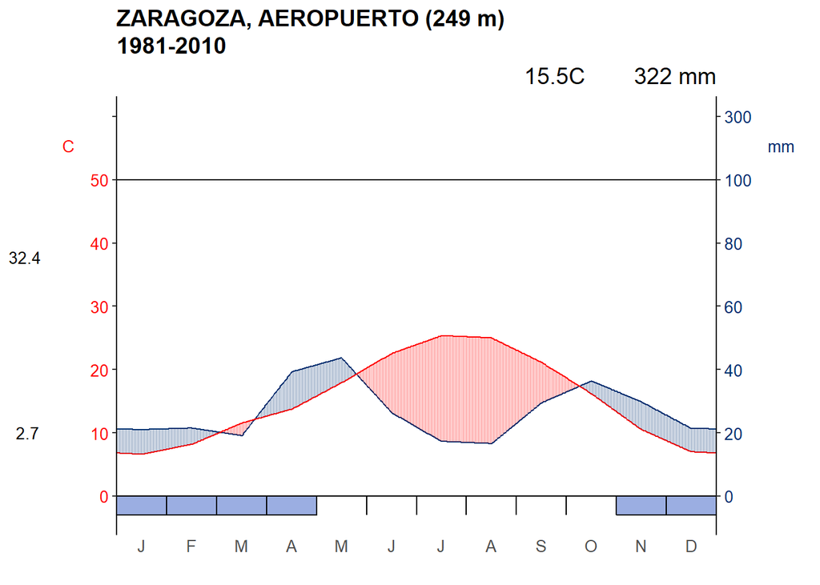

```r
#Diagrama climático de Walter & Lieth (Valores climático normales)
g2<-climatogram_normal("9434", verbose = FALSE, labels = "en")
g2
```

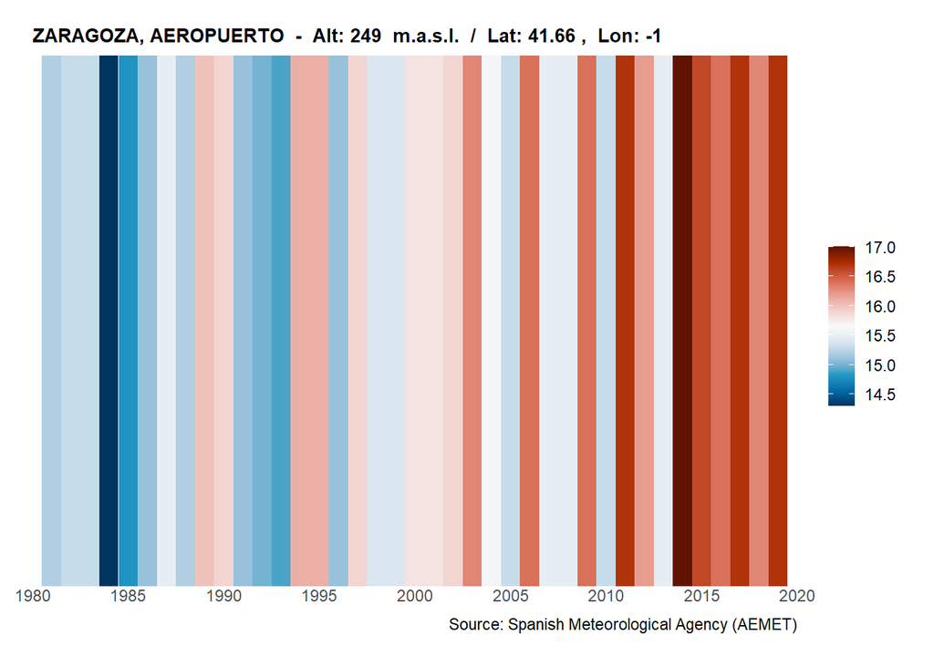

```r
#climate stripes graph
library(ggplot2)
g1<-climatestripes_station("9434",
                           key,start = 1980,
                           end = 2020,  verbose = FALSE)+
  theme(plot.title = element_text(size = 10))
g1
```

### Pregunta

*climaemet* no permite descargar datos de más de una estacíon meteo a la vez. Pero con los conocimientos adquiridos hasta ahora… ¿Se te ocurre una manera de descargar las últimas observaciones para las estaciones de la provincia en la que resides?

### Mini ejercicio

Exporta a archivo de texto separado por tabulaciones el objeto *estaciones*. Almacénalo en “~/outputs/aemet/estaciones.txt”.